# Death Rate ( Step-wise - Elastic penalized regression )

Mo’men Mohamed

April 9, 2019

this project is about predicating the death rate per 100000 person from more than 30 predictors

to find out more about this data and description of variables plz visit this [page](https://data.world/exercises/linear-regression-exercise-1/workspace/file?filename=cancer_reg.csv)

and for any advice or recommendation plz feel free to contact me : vet.m.mohamed@gmail.com

lets start with loading our libraries

```r
library(tidyverse)
library(knitr)
library(caret)
library(car)
library(psych)
library(mice)
library(progress)
library(DMwR)
library(readr)
library(MASS)
library(pedometrics)
```

then importing the data

```r
data<-read.csv("./data sets/cancer.csv")

head(data)%>%kable("markdown")
```

| avganncount | avgdeathsperyear | target_deathrate | incidencerate | medincome | popest2015 | povertypercent | studypercap | binnedinc | medianage | medianagemale | medianagefemale | geography | percentmarried | pctnohs18_24 | pcths18_24 | pctsomecol18_24 | pctbachdeg18_24 | pcths25_over | pctbachdeg25_over | pctemployed16_over | pctunemployed16_over | pctprivatecoverage | pctprivatecoveragealone | pctempprivcoverage | pctpubliccoverage | pctpubliccoveragealone | pctwhite | pctblack | pctasian | … |
| --- | --- | --- | --- | --- | --- | --- | --- | --- | --- | --- | --- | --- | --- | --- | --- | --- | --- | --- | --- | --- | --- | --- | --- | --- | --- | --- | --- | --- | --- | --- |
| 1397 | 469 | 164.9 | 489.8 | 61898 | 260131 | 11.2 | 499.74820 | (61494.5, 125635] | 39.3 | 36.9 | 41.7 | Kitsap County, Washington | 52.5 | 11.5 | 39.5 | 42.1 | 6.9 | 23.2 | 19.6 | 51.9 | 8.0 | 75.1 | NA | 41.6 | 32.9 | 14.0 | 81.78053 | 2.5947283 | 4.8218571 | … |
| 173 | 70 | 161.3 | 411.6 | 48127 | 43269 | 18.6 | 23.11123 | (48021.6, 51046.4] | 33.0 | 32.2 | 33.7 | Kittitas County, Washington | 44.5 | 6.1 | 22.4 | 64.0 | 7.5 | 26.0 | 22.7 | 55.9 | 7.8 | 70.2 | 53.8 | 43.6 | 31.1 | 15.3 | 89.22851 | 0.9691025 | 2.2462326 | … |
| 102 | 50 | 174.7 | 349.7 | 49348 | 21026 | 14.6 | 47.56016 | (48021.6, 51046.4] | 45.0 | 44.0 | 45.8 | Klickitat County, Washington | 54.2 | 24.0 | 36.6 | NA | 9.5 | 29.0 | 16.0 | 45.9 | 7.0 | 63.7 | 43.5 | 34.9 | 42.1 | 21.1 | 90.92219 | 0.7396734 | 0.4658982 | … |
| 427 | 202 | 194.8 | 430.4 | 44243 | 75882 | 17.1 | 342.63725 | (42724.4, 45201] | 42.8 | 42.2 | 43.4 | Lewis County, Washington | 52.7 | 20.2 | 41.2 | 36.1 | 2.5 | 31.6 | 9.3 | 48.3 | 12.1 | 58.4 | 40.3 | 35.0 | 45.3 | 25.0 | 91.74469 | 0.7826260 | 1.1613587 | … |
| 57 | 26 | 144.4 | 350.1 | 49955 | 10321 | 12.5 | 0.00000 | (48021.6, 51046.4] | 48.3 | 47.8 | 48.9 | Lincoln County, Washington | 57.8 | 14.9 | 43.0 | 40.0 | 2.0 | 33.4 | 15.0 | 48.2 | 4.8 | 61.6 | 43.9 | 35.1 | 44.0 | 22.7 | 94.10402 | 0.2701920 | 0.6658304 | … |
| 428 | 152 | 176.0 | 505.4 | 52313 | 61023 | 15.6 | 180.25990 | (51046.4, 54545.6] | 45.4 | 43.5 | 48.0 | Mason County, Washington | 50.4 | 29.9 | 35.1 | NA | 4.5 | 30.4 | 11.9 | 44.1 | 12.9 | 60.0 | 38.8 | 32.6 | 43.2 | 20.2 | 84.88263 | 1.6532052 | 1.5380566 | … |

it is important to see the structure of the data

```r
str(data)
```

```
## 'data.frame':    3047 obs. of  33 variables:
##  $ avganncount            : num  1397 173 102 427 57 ...
##  $ avgdeathsperyear       : int  469 70 50 202 26 152 97 71 36 1380 ...
##  $ target_deathrate       : num  165 161 175 195 144 ...
##  $ incidencerate          : num  490 412 350 430 350 ...
##  $ medincome              : int  61898 48127 49348 44243 49955 52313 37782 40189 42579 60397 ...
##  $ popest2015             : int  260131 43269 21026 75882 10321 61023 41516 20848 13088 843954 ...
##  $ povertypercent         : num  11.2 18.6 14.6 17.1 12.5 15.6 23.2 17.8 22.3 13.1 ...
##  $ studypercap            : num  499.7 23.1 47.6 342.6 0 ...
##  $ binnedinc              : Factor w/ 10 levels "(34218.1, 37413.8]",..: 9 6 6 4 6 7 2 2 3 8 ...
##  $ medianage              : num  39.3 33 45 42.8 48.3 45.4 42.6 51.7 49.3 35.8 ...
##  $ medianagemale          : num  36.9 32.2 44 42.2 47.8 43.5 42.2 50.8 48.4 34.7 ...
##  $ medianagefemale        : num  41.7 33.7 45.8 43.4 48.9 48 43.5 52.5 49.8 37 ...
##  $ geography              : Factor w/ 3047 levels "Abbeville County, South Carolina",..: 1459 1460 1464 1589 1618 1766 2051 2112 2143 2185 ...
##  $ percentmarried         : num  52.5 44.5 54.2 52.7 57.8 50.4 54.1 52.7 55.9 50 ...
```

[output cut: 19 more lines]

some of data are factors and others are numeric but there is no need for modification

Lets inspect the accuracy

```r
summary(data)
```

```
##   avganncount      avgdeathsperyear target_deathrate incidencerate
##  Min.   :    6.0   Min.   :    3    Min.   : 59.7    Min.   : 201.3
##  1st Qu.:   76.0   1st Qu.:   28    1st Qu.:161.2    1st Qu.: 420.3
##  Median :  171.0   Median :   61    Median :178.1    Median : 453.5
##  Mean   :  606.3   Mean   :  186    Mean   :178.7    Mean   : 448.3
##  3rd Qu.:  518.0   3rd Qu.:  149    3rd Qu.:195.2    3rd Qu.: 480.9
##  Max.   :38150.0   Max.   :14010    Max.   :362.8    Max.   :1206.9
##
##    medincome        popest2015       povertypercent   studypercap
##  Min.   : 22640   Min.   :     827   Min.   : 3.20   Min.   :   0.00
##  1st Qu.: 38883   1st Qu.:   11684   1st Qu.:12.15   1st Qu.:   0.00
##  Median : 45207   Median :   26643   Median :15.90   Median :   0.00
##  Mean   : 47063   Mean   :  102637   Mean   :16.88   Mean   : 155.40
##  3rd Qu.: 52492   3rd Qu.:   68671   3rd Qu.:20.40   3rd Qu.:  83.65
##  Max.   :125635   Max.   :10170292   Max.   :47.40   Max.   :9762.31
##
##               binnedinc      medianage      medianagemale
##  (45201, 48021.6]  : 306   Min.   : 22.30   Min.   :22.40
##  (54545.6, 61494.5]: 306   1st Qu.: 37.70   1st Qu.:36.35
##  [22640, 34218.1]  : 306   Median : 41.00   Median :39.60
##  (42724.4, 45201]  : 305   Mean   : 45.27   Mean   :39.57
##  (48021.6, 51046.4]: 305   3rd Qu.: 44.00   3rd Qu.:42.50
##  (51046.4, 54545.6]: 305   Max.   :624.00   Max.   :64.70
##  (Other)           :1214
##  medianagefemale                            geography    percentmarried
##  Min.   :22.30   Abbeville County, South Carolina:   1   Min.   :23.10
##  1st Qu.:39.10   Acadia Parish, Louisiana        :   1   1st Qu.:47.75
##  Median :42.40   Accomack County, Virginia       :   1   Median :52.40
##  Mean   :42.15   Ada County, Idaho               :   1   Mean   :51.77
##  3rd Qu.:45.30   Adair County, Iowa              :   1   3rd Qu.:56.40
##  Max.   :65.70   Adair County, Kentucky          :   1   Max.   :72.50
##                  (Other)                         :3041
##   pctnohs18_24     pcths18_24   pctsomecol18_24 pctbachdeg18_24
##  Min.   : 0.00   Min.   : 0.0   Min.   : 7.10   Min.   : 0.000
##  1st Qu.:12.80   1st Qu.:29.2   1st Qu.:34.00   1st Qu.: 3.100
##  Median :17.10   Median :34.7   Median :40.40   Median : 5.400
##  Mean   :18.22   Mean   :35.0   Mean   :40.98   Mean   : 6.158
##  3rd Qu.:22.70   3rd Qu.:40.7   3rd Qu.:46.40   3rd Qu.: 8.200
##  Max.   :64.10   Max.   :72.5   Max.   :79.00   Max.   :51.800
##                                 NA's   :2285
```

[output cut: 25 more lines]

```
##  Min.   : 0.0000   Min.   : 0.0000   Min.   : 0.0000
##  1st Qu.: 0.6207   1st Qu.: 0.2542   1st Qu.: 0.2952
##  Median : 2.2476   Median : 0.5498   Median : 0.8262
##  Mean   : 9.1080   Mean   : 1.2540   Mean   : 1.9835
##  3rd Qu.:10.5097   3rd Qu.: 1.2210   3rd Qu.: 2.1780
##  Max.   :85.9478   Max.   :42.6194   Max.   :41.9303
##
##  pctmarriedhouseholds   birthrate
##  Min.   :22.99        Min.   : 0.000
##  1st Qu.:47.76        1st Qu.: 4.521
##  Median :51.67        Median : 5.381
##  Mean   :51.24        Mean   : 5.640
##  3rd Qu.:55.40        3rd Qu.: 6.494
##  Max.   :78.08        Max.   :21.326
##
```

the summary reveal some issues with outliers and missing data

another thing , i think that we have to exclude the county name and keep only the name of the state

```r
table(data$geography)%>%data.frame()%>%head()%>%kable("markdown") #here we see that the number of county is the same of the number of data
```

| Var1 | Freq |
| --- | --- |
| Abbeville County, South Carolina | 1 |
| Acadia Parish, Louisiana | 1 |
| Accomack County, Virginia | 1 |
| Ada County, Idaho | 1 |
| Adair County, Iowa | 1 |
| Adair County, Kentucky | 1 |

```r
#this wil be problamitic in our analysis
#So i will keep the state name and remove the county name

data$geography<-str_remove_all(string = data$geography,
                               pattern = "[:alpha:]{1,}(\\s)|[:alpha:]{1,}(\\,)|(\\s)")


head(data,10)%>%kable("markdown")
```

| avganncount | avgdeathsperyear | target_deathrate | incidencerate | medincome | popest2015 | povertypercent | studypercap | binnedinc | medianage | medianagemale | medianagefemale | geography | percentmarried | pctnohs18_24 | pcths18_24 | pctsomecol18_24 | pctbachdeg18_24 | pcths25_over | pctbachdeg25_over | pctemployed16_over | pctunemployed16_over | pctprivatecoverage | pctprivatecoveragealone | pctempprivcoverage | pctpubliccoverage | pctpubliccoveragealone | pctwhite | pctblack | pctasian | … |
| --- | --- | --- | --- | --- | --- | --- | --- | --- | --- | --- | --- | --- | --- | --- | --- | --- | --- | --- | --- | --- | --- | --- | --- | --- | --- | --- | --- | --- | --- | --- |
| 1397 | 469 | 164.9 | 489.8 | 61898 | 260131 | 11.2 | 499.74820 | (61494.5, 125635] | 39.3 | 36.9 | 41.7 | Washington | 52.5 | 11.5 | 39.5 | 42.1 | 6.9 | 23.2 | 19.6 | 51.9 | 8.0 | 75.1 | NA | 41.6 | 32.9 | 14.0 | 81.78053 | 2.5947283 | 4.8218571 | … |
| 173 | 70 | 161.3 | 411.6 | 48127 | 43269 | 18.6 | 23.11123 | (48021.6, 51046.4] | 33.0 | 32.2 | 33.7 | Washington | 44.5 | 6.1 | 22.4 | 64.0 | 7.5 | 26.0 | 22.7 | 55.9 | 7.8 | 70.2 | 53.8 | 43.6 | 31.1 | 15.3 | 89.22851 | 0.9691025 | 2.2462326 | … |
| 102 | 50 | 174.7 | 349.7 | 49348 | 21026 | 14.6 | 47.56016 | (48021.6, 51046.4] | 45.0 | 44.0 | 45.8 | Washington | 54.2 | 24.0 | 36.6 | NA | 9.5 | 29.0 | 16.0 | 45.9 | 7.0 | 63.7 | 43.5 | 34.9 | 42.1 | 21.1 | 90.92219 | 0.7396734 | 0.4658982 | … |
| 427 | 202 | 194.8 | 430.4 | 44243 | 75882 | 17.1 | 342.63725 | (42724.4, 45201] | 42.8 | 42.2 | 43.4 | Washington | 52.7 | 20.2 | 41.2 | 36.1 | 2.5 | 31.6 | 9.3 | 48.3 | 12.1 | 58.4 | 40.3 | 35.0 | 45.3 | 25.0 | 91.74469 | 0.7826260 | 1.1613587 | … |
| 57 | 26 | 144.4 | 350.1 | 49955 | 10321 | 12.5 | 0.00000 | (48021.6, 51046.4] | 48.3 | 47.8 | 48.9 | Washington | 57.8 | 14.9 | 43.0 | 40.0 | 2.0 | 33.4 | 15.0 | 48.2 | 4.8 | 61.6 | 43.9 | 35.1 | 44.0 | 22.7 | 94.10402 | 0.2701920 | 0.6658304 | … |
| 428 | 152 | 176.0 | 505.4 | 52313 | 61023 | 15.6 | 180.25990 | (51046.4, 54545.6] | 45.4 | 43.5 | 48.0 | Washington | 50.4 | 29.9 | 35.1 | NA | 4.5 | 30.4 | 11.9 | 44.1 | 12.9 | 60.0 | 38.8 | 32.6 | 43.2 | 20.2 | 84.88263 | 1.6532052 | 1.5380566 | … |
| 250 | 97 | 175.9 | 461.8 | 37782 | 41516 | 23.2 | 0.00000 | (37413.8, 40362.7] | 42.6 | 42.2 | 43.5 | Washington | 54.1 | 26.1 | 41.4 | NA | 5.8 | 29.8 | 11.9 | 51.8 | 8.9 | 49.5 | 35.0 | 28.3 | 46.4 | 28.7 | 75.10645 | 0.6169554 | 0.8661570 | … |
| 146 | 71 | 183.6 | 404.0 | 40189 | 20848 | 17.8 | 0.00000 | (37413.8, 40362.7] | 51.7 | 50.8 | 52.5 | Washington | 52.7 | 27.3 | 33.9 | 36.5 | 2.2 | 31.6 | 11.3 | 40.9 | 8.9 | 55.8 | 33.1 | 25.9 | 50.9 | 24.1 | 89.40664 | 0.3051586 | 1.8890773 | … |
| 88 | 36 | 190.5 | 459.4 | 42579 | 13088 | 22.3 | 0.00000 | (40362.7, 42724.4] | 49.3 | 48.4 | 49.8 | Washington | 55.9 | 34.7 | 39.4 | NA | 1.4 | 32.2 | 12.0 | 39.5 | 10.3 | 55.5 | 37.8 | 29.9 | 48.1 | 26.6 | 91.78748 | 0.1850709 | 0.2082048 | … |
| 4025 | 1380 | 177.8 | 510.9 | 60397 | 843954 | 13.1 | 427.74843 | (54545.6, 61494.5] | 35.8 | 34.7 | 37.0 | Washington | 50.0 | 15.6 | 36.3 | NA | 7.1 | 28.8 | 16.2 | 56.6 | 9.2 | 69.9 | NA | 44.4 | 31.4 | 16.5 | 74.72967 | 6.7108542 | 6.0414720 | … |

good, now i think that we have to test for more than 5% missing value

```r
miss<-apply(data,2,function(x){
        round((sum(is.na(x))/length(x))*100,2)
})

miss
```

```
##             avganncount        avgdeathsperyear        target_deathrate
##                    0.00                    0.00                    0.00
##           incidencerate               medincome              popest2015
##                    0.00                    0.00                    0.00
##          povertypercent             studypercap               binnedinc
##                    0.00                    0.00                    0.00
##               medianage           medianagemale         medianagefemale
##                    0.00                    0.00                    0.00
##               geography          percentmarried            pctnohs18_24
##                    0.00                    0.00                    0.00
##              pcths18_24         pctsomecol18_24         pctbachdeg18_24
##                    0.00                   74.99                    0.00
##            pcths25_over       pctbachdeg25_over      pctemployed16_over
##                    0.00                    0.00                    4.99
##    pctunemployed16_over      pctprivatecoverage pctprivatecoveragealone
##                    0.00                    0.00                   19.99
##      pctempprivcoverage       pctpubliccoverage  pctpubliccoveragealone
##                    0.00                    0.00                    0.00
##                pctwhite                pctblack                pctasian
##                    0.00                    0.00                    0.00
##            pctotherrace    pctmarriedhouseholds               birthrate
##                    0.00                    0.00                    0.00
```

here we have 3 variable with missing values in my opinion , the most problematic one is the one which got 75% missing So i will Exclude it

```r
data<-data%>%dplyr::select(-which(miss>70))
```

OK , lets impute the rest using KNN method

```r
data<-cbind(knnImputation(data = data[,-c(9,13)]),binnedinc=data$binnedinc,
            geography=data$geography)%>%data.frame()
```

the next step , is my data got ouliers !! I think using Mahalanobis will answer this question

first excluding the categorical variable

```r
num<-data%>%dplyr::select(-geography,-binnedinc)
```

getting the mahalanobis value

```r
mah<-mahalanobis(x = num,center = colMeans(num),cov = cov(num))
```

Now calculating the cutoff points

```r
cutoff<-qchisq(p = .99,df = ncol(num))
```

lets open the surprise box :P

```r
summary(mah>cutoff)
```

```
##    Mode   FALSE    TRUE
## logical    2691     356
```

now we have 356 case which considered multivariate outlier

lets save it for later use

```r
outidx<-as.numeric(mah>cutoff)
```

testing additivity for multicolinearity is something crucial so lets test for correlation more than .9

```r
corr<-cor(num)%>%matrix(nrow = ncol(num),ncol = ncol(num))

addit<-apply(corr,2,function(x){
        ifelse(x>=abs(.9)&x<1,paste(round(x,2),"additive",sep = " ")," ")
})

colnames(addit)<-rownames(addit)<-names(num)
corvar<-names(data)[apply(addit,2,function(x){
        str_detect(x,"additive")
})%>%apply(MARGIN = 2,any)%>%which()]

corvar
```

```
## [1] "avganncount"             "avgdeathsperyear"
## [3] "popest2015"              "medianagemale"
## [5] "medianagefemale"         "pctprivatecoverage"
## [7] "pctprivatecoveragealone" "pctempprivcoverage"
```

```r
addit[corvar,corvar]%>%kable("markdown")
```

|  | avganncount | avgdeathsperyear | popest2015 | medianagemale | medianagefemale | pctprivatecoverage | pctprivatecoveragealone | pctempprivcoverage |
| --- | --- | --- | --- | --- | --- | --- | --- | --- |
| avganncount |  | 0.94 additive | 0.93 additive |  |  |  |  |  |
| avgdeathsperyear | 0.94 additive |  | 0.98 additive |  |  |  |  |  |
| popest2015 | 0.93 additive | 0.98 additive |  |  |  |  |  |  |
| medianagemale |  |  |  |  | 0.93 additive |  |  |  |
| medianagefemale |  |  |  | 0.93 additive |  |  |  |  |
| pctprivatecoverage |  |  |  |  |  |  | 0.93 additive |  |
| pctprivatecoveragealone |  |  |  |  |  | 0.93 additive |  | 0.92 additive |
| pctempprivcoverage |  |  |  |  |  |  | 0.92 additive |  |

we have here number of reported cancer (avganncount) and average reported mortality ( avgdeathsperyear) and number of population is highly correlated and we see that the number of population and average of reported mortality having no sense in predicting target death rate , so we will exclude them

```r
data<-data%>%dplyr::select(-popest2015,-avgdeathsperyear)
```

For the median age of males and females i will combine it together (x1+x2)/2

```r
data<-data%>%mutate(medianagemf=(medianagemale+medianagefemale)/2)%>%dplyr::select(-medianagefemale,-medianagemale)
```

For the median average of coverage and coverage alone and employee coverage i will make a linear function of them = .3*(x1+x2+x3)

```r
data<-data%>%mutate(medcov=.3*(pctprivatecoverage+pctprivatecoveragealone+pctempprivcoverage))%>%dplyr::select(-pctprivatecoverage,-pctprivatecoveragealone,-pctempprivcoverage)
```

run the correlation again

```r
num<-data%>%dplyr::select(-geography,-binnedinc)

corr2<-cor(num)

addit2<-apply(corr2,2,function(x){
        ifelse(x>=abs(.9)&x<1,paste(round(x,2),"additive",sep = " ")," ")
})

colnames(addit2)<-rownames(addit2)<-names(num)
corvar2<-names(data)[apply(addit2,2,function(x){
        str_detect(x,"additive")
})%>%apply(MARGIN = 2,any)%>%which()]

corvar2
```

```
## character(0)
```

Great, lets dive further in our analysis and run correlation with all variables

```r
fitall<-data%>%with(lm(target_deathrate~.,data=data))

summary(fitall)
```

```
##
## Call:
## lm(formula = target_deathrate ~ ., data = data)
##
## Residuals:
##      Min       1Q   Median       3Q      Max
## -111.540   -9.519   -0.299    9.934  126.239
##
## Coefficients:
##                               Estimate Std. Error t value Pr(>|t|)
## (Intercept)                  1.595e+02  1.759e+01   9.068  < 2e-16 ***
## avganncount                 -1.826e-04  3.040e-04  -0.601 0.548117
## incidencerate                1.843e-01  7.449e-03  24.745  < 2e-16 ***
## medincome                    7.827e-05  1.113e-04   0.703 0.482111
## povertypercent              -1.400e-01  1.785e-01  -0.784 0.432859
## studypercap                  4.214e-04  6.444e-04   0.654 0.513265
## medianage                    1.418e-03  7.383e-03   0.192 0.847700
## percentmarried               7.419e-01  1.690e-01   4.388 1.18e-05 ***
## pctnohs18_24                -2.640e-02  5.461e-02  -0.483 0.628851
## pcths18_24                   1.700e-01  4.850e-02   3.505 0.000463 ***
## pctbachdeg18_24             -2.272e-01  1.051e-01  -2.162 0.030666 *
## pcths25_over                 1.949e-01  1.077e-01   1.811 0.070309 .
## pctbachdeg25_over           -1.052e+00  1.578e-01  -6.666 3.13e-11 ***
## pctemployed16_over          -3.599e-01  1.144e-01  -3.147 0.001667 **
## pctunemployed16_over         3.332e-01  1.739e-01   1.916 0.055417 .
## pctpubliccoverage           -1.566e-01  2.237e-01  -0.700 0.483933
## pctpubliccoveragealone       7.008e-01  2.275e-01   3.080 0.002089 **
## pctwhite                    -1.939e-01  6.606e-02  -2.935 0.003362 **
## pctblack                    -1.771e-01  7.016e-02  -2.524 0.011655 *
## pctasian                    -6.877e-02  2.176e-01  -0.316 0.751941
## pctotherrace                -6.446e-01  1.298e-01  -4.965 7.27e-07 ***
## pctmarriedhouseholds        -1.050e+00  1.537e-01  -6.834 1.00e-11 ***
## birthrate                   -5.975e-01  1.853e-01  -3.224 0.001278 **
## binnedinc(37413.8, 40362.7] -1.933e+00  1.543e+00  -1.253 0.210454
## binnedinc(40362.7, 42724.4] -3.627e+00  1.661e+00  -2.184 0.029040 *
## binnedinc(42724.4, 45201]   -2.628e+00  1.819e+00  -1.445 0.148612
## binnedinc(45201, 48021.6]   -4.350e+00  1.993e+00  -2.183 0.029128 *
## binnedinc(48021.6, 51046.4] -5.388e+00  2.222e+00  -2.425 0.015384 *
## binnedinc(51046.4, 54545.6] -5.557e+00  2.426e+00  -2.291 0.022044 *
## binnedinc(54545.6, 61494.5] -4.792e+00  2.781e+00  -1.723 0.084907 .
```

[output cut: 63 more lines]

```
## geographyVermont            -1.301e+00  5.830e+00  -0.223 0.823396
## geographyVirginia            4.526e+00  2.796e+00   1.619 0.105647
## geographyWashington         -7.238e+00  4.025e+00  -1.798 0.072235 .
## geographyWisconsin          -4.402e+00  3.470e+00  -1.268 0.204730
## geographyWyoming            -4.566e+00  4.687e+00  -0.974 0.330105
## geographyYork               -1.387e+01  3.639e+00  -3.811 0.000141 ***
## geographyYukon-Alaska       -1.833e+01  1.879e+01  -0.975 0.329504
## medianagemf                 -4.697e-01  1.573e-01  -2.986 0.002847 **
## medcov                       2.000e-01  1.395e-01   1.433 0.151861
## ---
## Signif. codes:  0 '***' 0.001 '**' 0.01 '*' 0.05 '.' 0.1 ' ' 1
##
## Residual standard error: 18.06 on 2945 degrees of freedom
## Multiple R-squared:  0.5905, Adjusted R-squared:  0.5764
## F-statistic: 42.04 on 101 and 2945 DF,  p-value: < 2.2e-16
```

Now we can run regression diagnostics

firstly we can see the leverage points

```r
lev<-hatvalues(model = fitall)
```

next calculating the cutoff point = (2*K+2)/N

```r
k<-ncol(data)-1
hatcut<-((2*k)+2)/nrow(data)
```

lets see how many exceed the cutoff

```r
(lev>hatcut)%>%summary()
```

```
##    Mode   FALSE    TRUE
## logical    1096    1951
```

we have 1951 points which exceed the cutpoint

lets store it in variable

```r
levout<-as.numeric(lev>hatcut)
```

now we will test cook’s D for leverage and dispersion

```r
cook<-cooks.distance(fitall)
```

setting the cutoff point for cook’s distance

```r
cookcut<-(4/(nrow(data)-(ncol(data)-1)-1))
(cook>cookcut)%>%summary()
```

```
##    Mode   FALSE    TRUE    NA's
## logical    2889     143      15
```

here we have 143 cases which considered as influence with some misbehaving values returned to NA

```r
cookout<-as.numeric(cook>cookcut)
```

now we need to see the cases which is considered as outlier and influence

```r
totalout<-outidx+levout+cookout

table(totalout)
```

```
## totalout
##    0    1    2    3
## 1086 1538  330   78
```

```r
idx<-totalout>=2

idx<-sapply(idx,function(x){
        ifelse(is.na(x),TRUE,x)
})

table(idx)
```

```
## idx
## FALSE  TRUE
##  2624   423
```

```r
data<-data[-idx,]
```

here i think that we have to take a look on VIF for variables cause Inflation

```r
viftest<-vif(fitall)

viftest<-data.frame(viftest)

summary(viftest$GVIF>10)
```

```
##    Mode   FALSE    TRUE
## logical      17       9
```

```r
summary(viftest$GVIF..1..2.Df..>3.5)
```

```
##    Mode   FALSE    TRUE
## logical      21       5
```

i think that we face a great problem here regarding multicolinearity but i will delay any action for it to the end of our analysis

Now , lets test normality , linearity , homoscdasticity !!

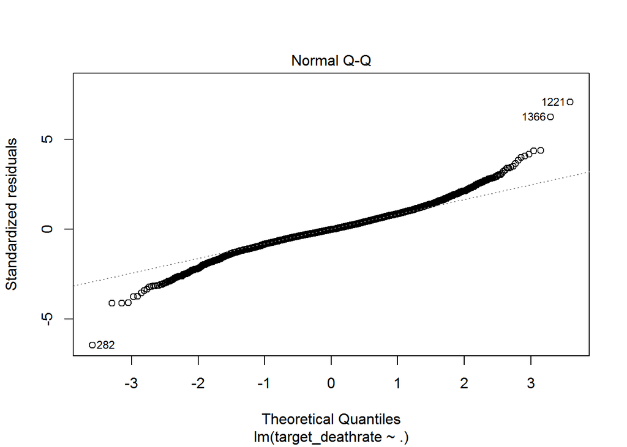

```r
stdresid<-rstudent(fitall)
stdfit<-fitted(fitall)%>%scale

plot(fitall,2)
```

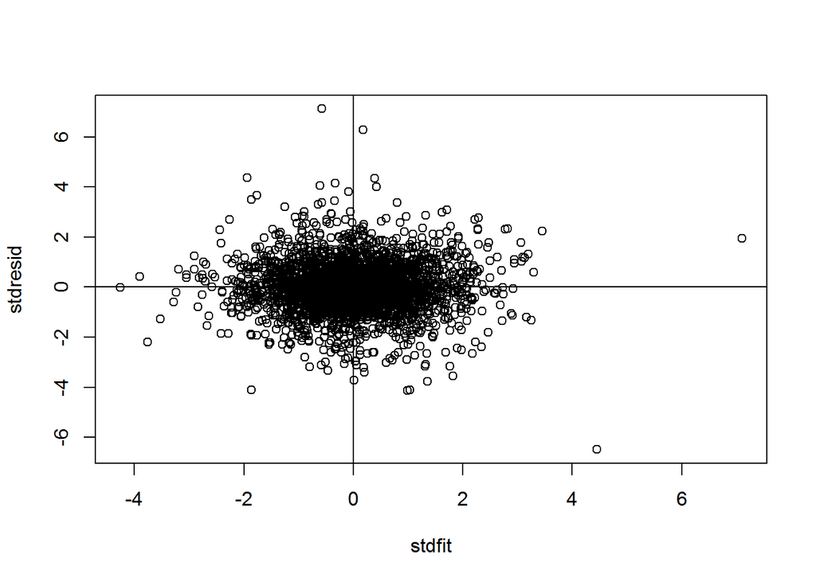

```r
plot(stdfit,stdresid)
abline(v = 0,h = 0)
```

firstly lets convert the categorical variables to dummy variables

```r
dummy<-dummyVars(target_deathrate~.,data=data)

data<-cbind(target_deathrate=data$target_deathrate,predict(dummy,data))%>%data.frame()
```

then partitioning our data

```r
set.seed(234)
trainidx<-createDataPartition(data$target_deathrate,p = .7,list = F)
traindata<-data[trainidx,]
testdata<-data[-trainidx,]
```

Now lets run all models consequently and doing 10 CV fold on the training data

```r
fitcontrol<-trainControl(method = "cv",number = 10)
```

all variables model

```r
allfit<-train(target_deathrate ~.,data = traindata,method="lm",trControl=fitcontrol)

summary(allfit)
```

```
##
## Call:
## lm(formula = .outcome ~ ., data = dat)
##
## Residuals:
##      Min       1Q   Median       3Q      Max
## -106.085   -9.712   -0.048   10.078  129.226
##
## Coefficients: (7 not defined because of singularities)
##                                Estimate Std. Error t value Pr(>|t|)
## (Intercept)                   1.430e+02  2.729e+01   5.239 1.78e-07 ***
## avganncount                  -3.536e-04  4.402e-04  -0.803 0.421936
## incidencerate                 1.812e-01  8.925e-03  20.301  < 2e-16 ***
## medincome                     1.608e-04  1.487e-04   1.081 0.279711
## povertypercent               -1.230e-01  2.179e-01  -0.564 0.572498
## studypercap                   1.005e-03  8.785e-04   1.144 0.252624
## medianage                     9.067e-03  9.151e-03   0.991 0.321892
## percentmarried                7.734e-01  2.066e-01   3.743 0.000187 ***
## pctnohs18_24                  1.095e-02  6.674e-02   0.164 0.869723
## pcths18_24                    2.071e-01  5.939e-02   3.487 0.000498 ***
## pctbachdeg18_24              -1.677e-01  1.289e-01  -1.302 0.193158
## pcths25_over                  2.010e-01  1.315e-01   1.528 0.126583
## pctbachdeg25_over            -1.177e+00  1.943e-01  -6.057 1.65e-09 ***
## pctemployed16_over           -2.887e-01  1.395e-01  -2.069 0.038632 *
## pctunemployed16_over          1.803e-01  2.155e-01   0.837 0.402943
## pctpubliccoverage            -1.399e-01  2.770e-01  -0.505 0.613709
## pctpubliccoveragealone        6.977e-01  2.785e-01   2.505 0.012313 *
## pctwhite                     -1.903e-01  8.064e-02  -2.360 0.018372 *
## pctblack                     -1.612e-01  8.608e-02  -1.873 0.061200 .
## pctasian                      8.381e-02  2.642e-01   0.317 0.751084
## pctotherrace                 -7.525e-01  1.689e-01  -4.455 8.86e-06 ***
## pctmarriedhouseholds         -1.187e+00  1.878e-01  -6.319 3.22e-10 ***
## birthrate                    -7.171e-01  2.293e-01  -3.128 0.001786 **
## binnedinc..34218.1..37413.8. -2.816e+00  2.074e+00  -1.358 0.174677
## binnedinc..37413.8..40362.7. -5.794e+00  2.341e+00  -2.475 0.013388 *
## binnedinc..40362.7..42724.4. -7.516e+00  2.590e+00  -2.902 0.003750 **
## binnedinc..42724.4..45201.   -7.803e+00  2.846e+00  -2.742 0.006155 **
## binnedinc..45201..48021.6.   -9.677e+00  3.147e+00  -3.076 0.002129 **
## binnedinc..48021.6..51046.4. -9.778e+00  3.485e+00  -2.806 0.005064 **
## binnedinc..51046.4..54545.6. -9.860e+00  3.751e+00  -2.628 0.008649 **
```

[output cut: 65 more lines]

```
## geography.Vermont             1.628e+01  2.032e+01   0.801 0.423092
## geography.Virginia            2.273e+01  1.936e+01   1.174 0.240515
## geography.Washington          1.220e+01  1.965e+01   0.621 0.534733
## geography.Wisconsin           1.580e+01  1.948e+01   0.811 0.417536
## geography.Wyoming             1.855e+01  1.977e+01   0.938 0.348258
## geography.York                5.149e+00  1.959e+01   0.263 0.792662
## geography.Yukon.Alaska               NA         NA      NA       NA
## medianagemf                  -4.849e-01  1.890e-01  -2.565 0.010377 *
## medcov                        2.076e-01  1.704e-01   1.218 0.223330
## ---
## Signif. codes:  0 '***' 0.001 '**' 0.01 '*' 0.05 '.' 0.1 ' ' 1
##
## Residual standard error: 18.45 on 2037 degrees of freedom
## Multiple R-squared:  0.5858, Adjusted R-squared:  0.5663
## F-statistic: 30.01 on 96 and 2037 DF,  p-value: < 2.2e-16
```

OK , the factor predictor of states is misbehave and rarely be significant

our data matrix is at least equal to the number of parameters we want to fit. One way to invoke it is having some col-linear covariates which exist in our data

Now lets test step-wise regression

```r
stepfit<-train(target_deathrate ~.,data = traindata,method="lmStepAIC",trControl=fitcontrol)
```

Seeing the summary and the coefficients

```r
summary(stepfit)
```

```
##
## Call:
## lm(formula = .outcome ~ incidencerate + percentmarried + pcths18_24 +
##     pcths25_over + pctbachdeg25_over + pctemployed16_over + pctpubliccoveragealone +
##     pctwhite + pctblack + pctotherrace + pctmarriedhouseholds +
##     birthrate + binnedinc..37413.8..40362.7. + binnedinc..40362.7..42724.4. +
##     binnedinc..42724.4..45201. + binnedinc..45201..48021.6. +
##     binnedinc..48021.6..51046.4. + binnedinc..51046.4..54545.6. +
##     binnedinc..54545.6..61494.5. + geography.Alabama + geography.Alaska +
##     geography.Arkansas + geography.Carolina + geography.Dakota +
##     geography.Florida + geography.Georgia + geography.Hampshire +
##     geography.Illinois + geography.Indiana + geography.Jersey +
##     geography.Kansas + geography.Kentucky + geography.Louisiana +
##     geography.Maine + geography.Maryland + geography.Michigan +
##     geography.Mississippi + geography.Missouri + geography.Nebraska +
##     geography.Nevada + geography.Ohio + geography.Oklahoma +
##     geography.Oregon + geography.Pennsylvania + geography.St.Louisiana +
##     geography.St.Missouri + geography.St.Wisconsin + geography.Ste.Missouri +
##     geography.Tennessee + geography.Texas + geography.Valdez.Alaska +
##     geography.Vermont + geography.Virginia + geography.Washington +
##     geography.Wisconsin + geography.Wyoming + medianagemf + medcov,
##     data = dat)
##
## Residuals:
##     Min      1Q  Median      3Q     Max
## -107.36   -9.90   -0.32   10.21  127.41
##
## Coefficients:
##                               Estimate Std. Error t value Pr(>|t|)
## (Intercept)                  143.23047   13.66199  10.484  < 2e-16 ***
## incidencerate                  0.18560    0.00843  22.017  < 2e-16 ***
## percentmarried                 0.74211    0.19298   3.846 0.000124 ***
## pcths18_24                     0.21462    0.05389   3.983 7.04e-05 ***
## pcths25_over                   0.19695    0.12299   1.601 0.109448
## pctbachdeg25_over             -1.26662    0.17688  -7.161 1.11e-12 ***
## pctemployed16_over            -0.25453    0.10904  -2.334 0.019672 *
## pctpubliccoveragealone         0.61463    0.17141   3.586 0.000344 ***
## pctwhite                      -0.18170    0.06631  -2.740 0.006198 **
## pctblack                      -0.13647    0.07520  -1.815 0.069705 .
## pctotherrace                  -0.74841    0.15452  -4.844 1.37e-06 ***
```

[output cut: 39 more lines]

```
## geography.Texas               16.03179    2.01293   7.964 2.71e-15 ***
## geography.Valdez.Alaska       40.64590   18.56773   2.189 0.028703 *
## geography.Vermont              9.17605    5.82503   1.575 0.115344
## geography.Virginia            16.60272    2.09694   7.918 3.91e-15 ***
## geography.Washington           6.41982    3.78538   1.696 0.090045 .
## geography.Wisconsin            9.82176    2.97262   3.304 0.000969 ***
## geography.Wyoming             12.83993    4.66086   2.755 0.005923 **
## medianagemf                   -0.49429    0.13133  -3.764 0.000172 ***
## medcov                         0.22289    0.13775   1.618 0.105797
## ---
## Signif. codes:  0 '***' 0.001 '**' 0.01 '*' 0.05 '.' 0.1 ' ' 1
##
## Residual standard error: 18.39 on 2075 degrees of freedom
## Multiple R-squared:  0.5808, Adjusted R-squared:  0.569
## F-statistic: 49.56 on 58 and 2075 DF,  p-value: < 2.2e-16
```

Now the final model is penalized model

Penalized Model has three type :

1- lasso model 2- ridge model 3- Elsatic Model

here i will use elastic model since we have alot of colinear variable which to need to be tru zero and others which need only to be zero

lets run elastic model

```r
elasticfit<-train(target_deathrate~.,data = traindata,trControl=fitcontrol,tuneLength=10,method="glmnet")

elasticfit$bestTune # best alpha and lambda values
```

```
##   alpha    lambda
## 7   0.1 0.9404475
```

```r
coef(elasticfit$finalModel,elasticfit$bestTune$lambda)
```

```
## 104 x 1 sparse Matrix of class "dgCMatrix"
##                                          1
## (Intercept)                   1.345691e+02
## avganncount                  -1.895949e-04
## incidencerate                 1.754294e-01
## medincome                     .
## povertypercent                .
## studypercap                   7.542099e-04
## medianage                     5.913347e-03
## percentmarried                1.885861e-01
## pctnohs18_24                  .
## pcths18_24                    2.164261e-01
## pctbachdeg18_24              -1.353659e-01
## pcths25_over                  2.457405e-01
## pctbachdeg25_over            -1.000302e+00
## pctemployed16_over           -7.355091e-02
## pctunemployed16_over          2.498321e-01
## pctpubliccoverage             .
## pctpubliccoveragealone        4.244808e-01
## pctwhite                     -4.779651e-02
## pctblack                     -5.773841e-03
## pctasian                      9.954008e-02
## pctotherrace                 -6.145021e-01
## pctmarriedhouseholds         -6.034101e-01
## birthrate                    -5.503060e-01
## binnedinc..34218.1..37413.8.  3.433645e+00
## binnedinc..37413.8..40362.7.  8.489800e-01
## binnedinc..40362.7..42724.4.  .
## binnedinc..42724.4..45201.    .
## binnedinc..45201..48021.6.   -9.928822e-01
## binnedinc..48021.6..51046.4. -1.149099e+00
## binnedinc..51046.4..54545.6. -1.139128e+00
## binnedinc..54545.6..61494.5. -1.229785e-01
## binnedinc..61494.5..125635.   8.941259e-01
## binnedinc..22640..34218.1.    5.146713e+00
## geography.Alabama             1.154804e+00
## geography.Alaska              1.733174e+01
## geography.Anne.Maryland       .
## geography.Arizona            -1.688474e+01
## geography.Arkansas            1.151172e+01
```

[output cut: 51 more lines]

```
## geography.St.York            -3.102247e+00
## geography.Ste.Missouri        1.793544e+01
## geography.Tennessee           6.971448e+00
## geography.Texas               2.159052e+00
## geography.Utah               -1.746181e+01
## geography.Valdez.Alaska       2.170245e+01
## geography.Vermont            -1.148873e+00
## geography.Virginia            4.644171e+00
## geography.Washington         -3.895516e+00
## geography.Wisconsin          -6.244107e-01
## geography.Wyoming             .
## geography.York               -1.102549e+01
## geography.Yukon.Alaska       -4.383698e+00
## medianagemf                  -3.506919e-01
## medcov                        .
```

finally we need to predict the test data to Extract RMSE and R2

```r
allfitpred<-predict(allfit,testdata)
allfitmeasures<-data.frame(RMSE=RMSE(pred = allfitpred,obs = testdata$target_deathrate),R2=R2(pred = allfitpred,obs = testdata$target_deathrate))

stepfitpred<-predict(stepfit,testdata)
stepfitmeasures<-data.frame(RMSE=RMSE(pred = stepfitpred,obs = testdata$target_deathrate),R2=R2(pred = stepfitpred,obs = testdata$target_deathrate))

elasticfitpred<-predict(elasticfit,testdata)
elasticfitmeasures<-data.frame(RMSE=RMSE(pred = elasticfitpred,obs = testdata$target_deathrate),R2=R2(pred = elasticfitpred,obs = testdata$target_deathrate))
```

putting all measures together

```r
allmeasures<-rbind(allfitmeasures,stepfitmeasures,elasticfitmeasures)

rownames(allmeasures)<-c("Model with all variables","stepwise model","elastic penalized model")

allmeasures%>%kable("markdown")
```

|  | RMSE | R2 |
| --- | --- | --- |
| Model with all variables | 17.58857 | 0.5793748 |
| stepwise model | 17.61035 | 0.5782697 |
| elastic penalized model | 17.43842 | 0.5866667 |

this was an effort to achieve the best prediction of death rate using more than 30 variables

Regards